## **Heath mouse**

### Blamed on foxes

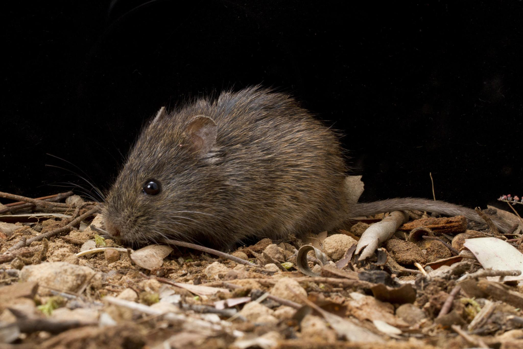

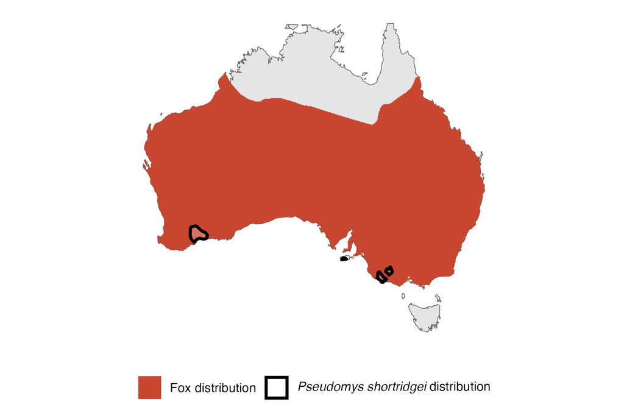

IUCN status: **Near Threatened**

EPBC Predator Threat Rating: **Not assessed**

IUCN claim: *“Predation by Red Foxes (Vulpes vulpes; moderate, entire range): plausible, but impact not known; impact likely to be less in dense vegetation.”*

### Studies not in support

No studies

### Is the threat claim evidence-based?

Foxes have been documented among a range of ecological variables negatively correlated with heath mouse abundance in one study. Causality for decline cannot be inferred due to confounding variables.

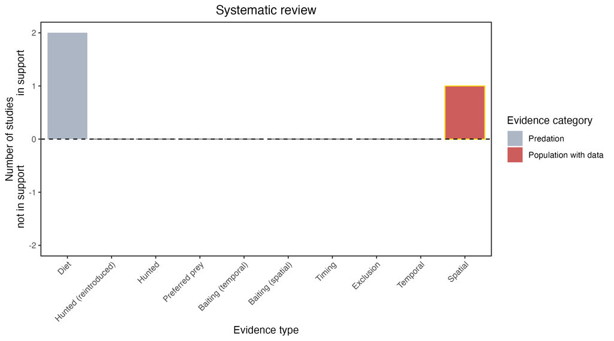

**Evidence linking *Pseudomys shortridgei* to foxes.** Systematic review of evidence for an association between *Pseudomys shortridgei* and foxes. Positive studies are in support of the hypothesis that *foxes* contribute to the decline of Pseudomys shortridgei, negative studies are not in support. Predation studies include studies documenting hunting or scavenging; baiting studies are associations between poison baiting and threatened mammal abundance where information on predator abundance is not provided; population studies are associations between threatened mammal and predator abundance. Gold borders indicate studies that meet qualities of scientific rigour. See methods section in Wallach and Lundgren 2025 for details on evidence categories.

### References

Davis, N.E., Forsyth, D.M., Triggs, B., Pascoe, C., Benshemesh, J., Robley, A., Lawrence, J., Ritchie, E.G., Nimmo, D.G. and Lumsden, L.F., 2015. Interspecific and geographic variation in the diets of sympatric carnivores: dingoes/wild dogs and red foxes in south-eastern Australia. PloS One, 10(3), p.e0120975.

IUCN Red List. https://www.iucnredlist.org/ Accessed June 2023

Nalliah, R., Sitters, H., Smith, A., & Di Stefano, J. 2021. Untangling the influences of fire, habitat and introduced predators on the endangered heath mouse. Animal Conservation. doi:10.1111/acv.12731

Sinclair, R., 2020. The diet of foxes in the Grampians (Gariwerd) National Park. Doctoral dissertation, Deakin University.

Wallach A.D., Lundgren E.J. (2025) Review of evidence that foxes and cats cause extinctions of Australia’s endemic mammals. BioScience. DOI: 10.1093/biosci/biaf046